# Wine recognition

Dataset consists of 178 observations with 13 independent variables, classifying wine into 3 categories. Data source: [scikit-learn](https://scikit-learn.org/stable/modules/generated/sklearn.datasets.load_wine.html).

Avalaible features:

```
['alcohol',
 'malic_acid',
 'ash',
 'alcalinity_of_ash',
 'magnesium',
 'total_phenols',
 'flavanoids',
 'nonflavanoid_phenols',
 'proanthocyanins',
 'color_intensity',
 'hue',
 'od280/od315_of_diluted_wines',
 'proline']
```

Proportion of target classes:

```
1    0.398876
0    0.331461
2    0.269663
Name: target, dtype: float64
```

Although data is balanced, stratification will be used to preserve target proportions.

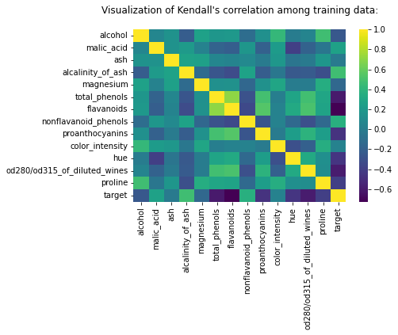

## First model - gradient boosting

```
GradientBoostingClassifier(learning_rate=0.5, n_estimators=10, random_state=256)
```

```
Accuracy on train set: 1.0000
Accuracy on test set: 0.9556
```

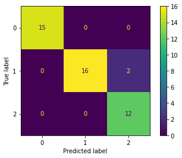

Gradient boosting model has some problems with differentiating between `class_1` and `class_2`.

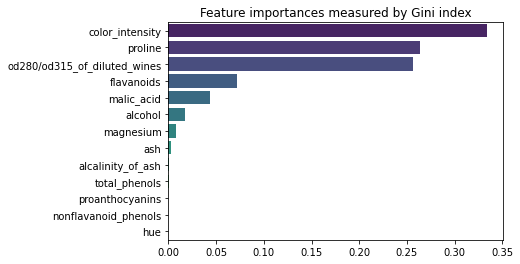

### Explanations

```
Indices of incorrectly classified test examples: [13 27]
```

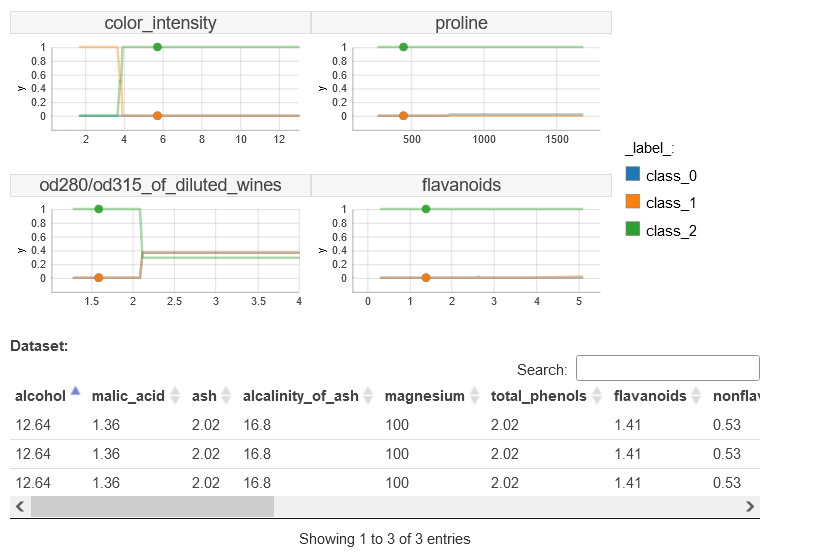

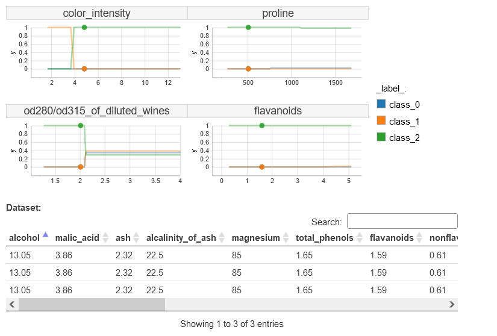

Observations:

- both examples are incorrectly classified as `class_2` with high probability (instead of `class_1`),
- change in flavanoids/proline does not impact model's prediction in these cases, even though proline has second largest Gini index value,
- low color intensity would change model's prediction to `class_1`,
- average or high OD ratio would result in high uncertainty (predictions for all classes would be around $\frac{1}{3}$),
- both examples have color intensity above average for `class_1`,
- both examples have OD ratio below average for `class_1`.

CP plots are roughly same for these two misclassified examples, so let's look for more variety.

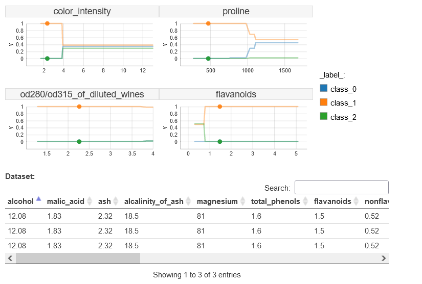

Observations:

- this example is correctly classified as `class_1` with high probability,
- change in OD ratio does not impact model's prediction in this case,
- average or high color intensity would result in high uncertainty (predictions for all classes would be around $\frac{1}{3}$),
- high values of proline would move predictions towards `class_0`,
- low values of flavanoids would more predictions toward `class_2`.

## Second model - random forest

```
RandomForestClassifier(random_state=256)
```

```
Accuracy on train set: 1.0000
Accuracy on test set: 0.9111
```

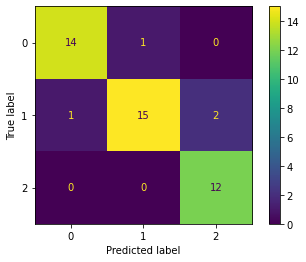

Random forest is clearly overfitting and struggles with predicting `class_1`.

```
Indices of incorrectly classified test examples: [13 16 27 30]
```

## Model comparison

```
Observation index chosen for model comparison 30
```

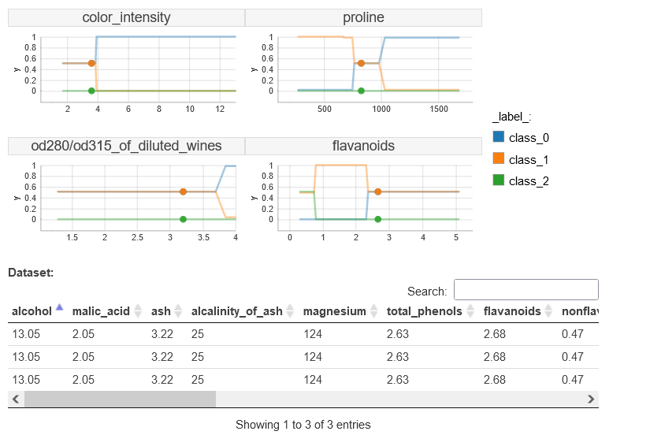

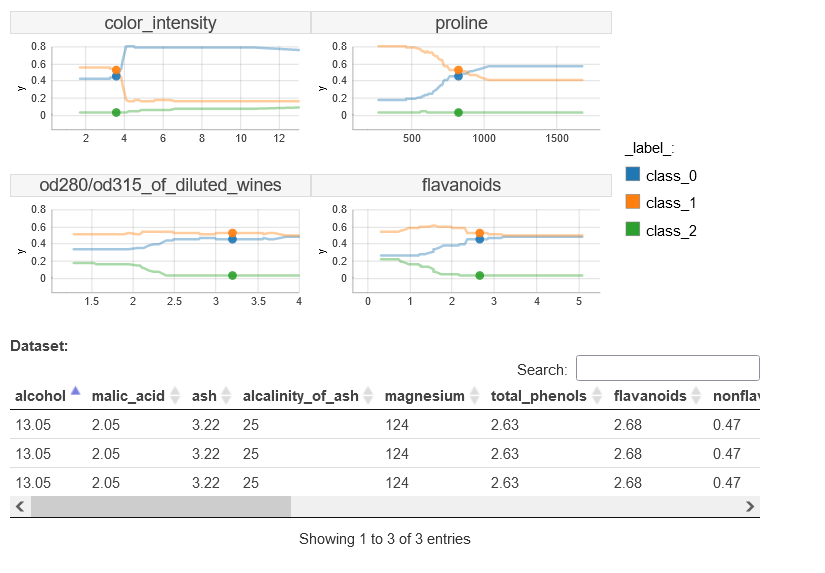

Comments:

- both models hesitate in between `class_0` (correct one) and `class_1`,
- for both models color intensity at inflection point between predicting `class_0` and `class_1`,
- for second model there is no change that would make `class_2` probable, while very low value of flavanoids would shift first model's prediction towards it,
- cutoffs for first model's predictions are more visible, what could be caused by a low number of used trees (only 10 estimators).